# Chapter6

2023-12-09

# Chapter 5

## Data wrangling

**Load the data sets (BPRS and RATS) and analyze the dataset**

```r
library(tidyverse)
```

```r
library(tidyr)
library(ggplot2)
# Save the url in a object

url_data1 <- "https://raw.githubusercontent.com/KimmoVehkalahti/MABS/master/Examples/data/BPRS.txt"

url_data2 <- "https://raw.githubusercontent.com/KimmoVehkalahti/MABS/master/Examples/data/rats.txt"

# read the data and save it as an object
BPRS <- read.table(url_data1, header = TRUE, sep = ' ')
RATS <- read.table(url_data2, sep ='\t', header = T)
```

Check the variable names, view the data contents and structures, and create some brief summaries of the variables , so that you understand the point of the wide form data. (1 point)

```r
#BPRS dataset
str(BPRS)
```

```
## 'data.frame':    40 obs. of  11 variables:
##  $ treatment: int  1 1 1 1 1 1 1 1 1 1 ...
##  $ subject  : int  1 2 3 4 5 6 7 8 9 10 ...
##  $ week0    : int  42 58 54 55 72 48 71 30 41 57 ...
##  $ week1    : int  36 68 55 77 75 43 61 36 43 51 ...
##  $ week2    : int  36 61 41 49 72 41 47 38 39 51 ...
##  $ week3    : int  43 55 38 54 65 38 30 38 35 55 ...
##  $ week4    : int  41 43 43 56 50 36 27 31 28 53 ...
##  $ week5    : int  40 34 28 50 39 29 40 26 22 43 ...
##  $ week6    : int  38 28 29 47 32 33 30 26 20 43 ...
##  $ week7    : int  47 28 25 42 38 27 31 25 23 39 ...
##  $ week8    : int  51 28 24 46 32 25 31 24 21 32 ...
```

```r
glimpse(BPRS)
```

```
## Rows: 40
## Columns: 11
## $ treatment <int> 1, 1, 1, 1, 1, 1, 1, 1, 1, 1, 1, 1, 1, 1, 1, 1, 1, 1, 1, 1, …
## $ subject   <int> 1, 2, 3, 4, 5, 6, 7, 8, 9, 10, 11, 12, 13, 14, 15, 16, 17, 1…
## $ week0     <int> 42, 58, 54, 55, 72, 48, 71, 30, 41, 57, 30, 55, 36, 38, 66, …
## $ week1     <int> 36, 68, 55, 77, 75, 43, 61, 36, 43, 51, 34, 52, 32, 35, 68, …
## $ week2     <int> 36, 61, 41, 49, 72, 41, 47, 38, 39, 51, 34, 49, 36, 36, 65, …
## $ week3     <int> 43, 55, 38, 54, 65, 38, 30, 38, 35, 55, 41, 54, 31, 34, 49, …
## $ week4     <int> 41, 43, 43, 56, 50, 36, 27, 31, 28, 53, 36, 48, 25, 25, 36, …
## $ week5     <int> 40, 34, 28, 50, 39, 29, 40, 26, 22, 43, 36, 43, 25, 27, 32, …
## $ week6     <int> 38, 28, 29, 47, 32, 33, 30, 26, 20, 43, 38, 37, 21, 25, 27, …
## $ week7     <int> 47, 28, 25, 42, 38, 27, 31, 25, 23, 39, 36, 36, 19, 26, 30, …
## $ week8     <int> 51, 28, 24, 46, 32, 25, 31, 24, 21, 32, 36, 31, 22, 26, 37, …
```

```r
dim(BPRS)
```

```
## [1] 40 11
```

```r
summary(BPRS)
```

```
##    treatment      subject          week0           week1           week2
##  Min.   :1.0   Min.   : 1.00   Min.   :24.00   Min.   :23.00   Min.   :26.0
##  1st Qu.:1.0   1st Qu.: 5.75   1st Qu.:38.00   1st Qu.:35.00   1st Qu.:32.0
##  Median :1.5   Median :10.50   Median :46.00   Median :41.00   Median :38.0
##  Mean   :1.5   Mean   :10.50   Mean   :48.00   Mean   :46.33   Mean   :41.7
##  3rd Qu.:2.0   3rd Qu.:15.25   3rd Qu.:58.25   3rd Qu.:54.25   3rd Qu.:49.0
##  Max.   :2.0   Max.   :20.00   Max.   :78.00   Max.   :95.00   Max.   :75.0
##      week3           week4           week5           week6           week7
##  Min.   :24.00   Min.   :20.00   Min.   :20.00   Min.   :19.00   Min.   :18.0
##  1st Qu.:29.75   1st Qu.:28.00   1st Qu.:26.00   1st Qu.:22.75   1st Qu.:23.0
##  Median :36.50   Median :34.50   Median :30.50   Median :28.50   Median :30.0
##  Mean   :39.15   Mean   :36.35   Mean   :32.55   Mean   :31.23   Mean   :32.2
##  3rd Qu.:44.50   3rd Qu.:43.00   3rd Qu.:38.00   3rd Qu.:37.00   3rd Qu.:38.0
##  Max.   :76.00   Max.   :66.00   Max.   :64.00   Max.   :64.00   Max.   :62.0
##      week8
##  Min.   :20.00
##  1st Qu.:22.75
##  Median :28.00
##  Mean   :31.43
##  3rd Qu.:35.25
##  Max.   :75.00
```

The data shows analyze of BPRS for different participants (20). There are no groups for participants, but we have 2 types of treatment which we can consider as 2 groups. The max BPRS over the weeks is 95 and the min is 18. The PBRS changes every day in term of min, max, median and mean. The variables treatment and subject are integer -> need to be changed to factor for further analyzes. We have 40 rows 40 and 11 columns -> format is wide -> needs to be changed to long format.

```r
#RATS
str(RATS)
```

```
## 'data.frame':    16 obs. of  13 variables:
##  $ ID   : int  1 2 3 4 5 6 7 8 9 10 ...
##  $ Group: int  1 1 1 1 1 1 1 1 2 2 ...
##  $ WD1  : int  240 225 245 260 255 260 275 245 410 405 ...
##  $ WD8  : int  250 230 250 255 260 265 275 255 415 420 ...
##  $ WD15 : int  255 230 250 255 255 270 260 260 425 430 ...
##  $ WD22 : int  260 232 255 265 270 275 270 268 428 440 ...
##  $ WD29 : int  262 240 262 265 270 275 273 270 438 448 ...
##  $ WD36 : int  258 240 265 268 273 277 274 265 443 460 ...
##  $ WD43 : int  266 243 267 270 274 278 276 265 442 458 ...
##  $ WD44 : int  266 244 267 272 273 278 271 267 446 464 ...
##  $ WD50 : int  265 238 264 274 276 284 282 273 456 475 ...
##  $ WD57 : int  272 247 268 273 278 279 281 274 468 484 ...
##  $ WD64 : int  278 245 269 275 280 281 284 278 478 496 ...
```

```r
glimpse(RATS)
```

```
## Rows: 16
## Columns: 13
## $ ID    <int> 1, 2, 3, 4, 5, 6, 7, 8, 9, 10, 11, 12, 13, 14, 15, 16
## $ Group <int> 1, 1, 1, 1, 1, 1, 1, 1, 2, 2, 2, 2, 3, 3, 3, 3
## $ WD1   <int> 240, 225, 245, 260, 255, 260, 275, 245, 410, 405, 445, 555, 470,…
## $ WD8   <int> 250, 230, 250, 255, 260, 265, 275, 255, 415, 420, 445, 560, 465,…
## $ WD15  <int> 255, 230, 250, 255, 255, 270, 260, 260, 425, 430, 450, 565, 475,…
## $ WD22  <int> 260, 232, 255, 265, 270, 275, 270, 268, 428, 440, 452, 580, 485,…
## $ WD29  <int> 262, 240, 262, 265, 270, 275, 273, 270, 438, 448, 455, 590, 487,…
## $ WD36  <int> 258, 240, 265, 268, 273, 277, 274, 265, 443, 460, 455, 597, 493,…
## $ WD43  <int> 266, 243, 267, 270, 274, 278, 276, 265, 442, 458, 451, 595, 493,…
## $ WD44  <int> 266, 244, 267, 272, 273, 278, 271, 267, 446, 464, 450, 595, 504,…
## $ WD50  <int> 265, 238, 264, 274, 276, 284, 282, 273, 456, 475, 462, 612, 507,…
## $ WD57  <int> 272, 247, 268, 273, 278, 279, 281, 274, 468, 484, 466, 618, 518,…
## $ WD64  <int> 278, 245, 269, 275, 280, 281, 284, 278, 478, 496, 472, 628, 525,…
```

```r
dim(RATS)
```

```
## [1] 16 13
```

```r
summary(RATS)
```

```
##        ID            Group           WD1             WD8             WD15
##  Min.   : 1.00   Min.   :1.00   Min.   :225.0   Min.   :230.0   Min.   :230.0
##  1st Qu.: 4.75   1st Qu.:1.00   1st Qu.:252.5   1st Qu.:255.0   1st Qu.:255.0
##  Median : 8.50   Median :1.50   Median :340.0   Median :345.0   Median :347.5
##  Mean   : 8.50   Mean   :1.75   Mean   :365.9   Mean   :369.1   Mean   :372.5
##  3rd Qu.:12.25   3rd Qu.:2.25   3rd Qu.:480.0   3rd Qu.:476.2   3rd Qu.:486.2
##  Max.   :16.00   Max.   :3.00   Max.   :555.0   Max.   :560.0   Max.   :565.0
##       WD22            WD29            WD36            WD43
##  Min.   :232.0   Min.   :240.0   Min.   :240.0   Min.   :243.0
##  1st Qu.:267.2   1st Qu.:268.8   1st Qu.:267.2   1st Qu.:269.2
##  Median :351.5   Median :356.5   Median :360.0   Median :360.0
##  Mean   :379.2   Mean   :383.9   Mean   :387.0   Mean   :386.0
##  3rd Qu.:492.5   3rd Qu.:497.8   3rd Qu.:504.2   3rd Qu.:501.0
##  Max.   :580.0   Max.   :590.0   Max.   :597.0   Max.   :595.0
##       WD44            WD50            WD57            WD64
##  Min.   :244.0   Min.   :238.0   Min.   :247.0   Min.   :245.0
##  1st Qu.:270.0   1st Qu.:273.8   1st Qu.:273.8   1st Qu.:278.0
##  Median :362.0   Median :370.0   Median :373.5   Median :378.0
##  Mean   :388.3   Mean   :394.6   Mean   :398.6   Mean   :404.1
##  3rd Qu.:510.5   3rd Qu.:516.0   3rd Qu.:524.5   3rd Qu.:530.8
##  Max.   :595.0   Max.   :612.0   Max.   :618.0   Max.   :628.0
```

The data shows weight for different rats (16) at different time from 1 to 64. Each rat belongs to a different group. There are 3 groups. The max weight over the weeks is 628 and the min weight is 225. The mean changes every day in term of min, max, median and mean. The variables ID and group are integer -> need to be changed to factor for further analyzes. There are 16 rows and 13 columns -> format is wide and needs to be changed to long format.

**2. Convert the categorical variables to factors**

```r
#BPRS
BPRS$treatment <- factor(BPRS$treatment)
BPRS$subject <- factor(BPRS$subject)

# RATS
RATS$ID <- factor(RATS$ID )
RATS$Group <- factor(RATS$Group)
```

**3. Convert the table to long form**

Add a week variable to BPRS and a Time variable to RATS > reorder by period of time (week or WD) > add one column where the week or WD is an integer.

BPRS

```r
BPRS_long <- pivot_longer(BPRS, cols = -c(treatment, subject), # columns are not pivoted, they are returned as they are
                       names_to = "weeks", values_to = "bprs") %>% # names_to is the new column created for the former column titles, the values_to is the new column created for the values
          arrange(weeks) %>% # order by weeks variable
            mutate(week = as.integer(substr(weeks,5,5)))
```

RATS

```r
RATS_long <- pivot_longer(RATS, cols = -c(ID, Group),
                       names_to = "WD", values_to = "weight") %>%
  arrange(WD) %>%
  mutate(Time = as.integer(substr(WD,3,4)))
```

**Compare wide vs long format**

Now, take a serious look at the new data sets and compare them with their wide form versions: Check the variable names, view the data contents and structures, and create some brief summaries of the variables. Make sure that you understand the point of the long form data and the crucial difference between the wide and the long forms before proceeding the to Analysis exercise. (2 points)

> Long format data allow for a more detailed examination of individual measurements, making it easier to assess the impact of various factors on the outcome. This format also facilitates the application of statistical methods designed for longitudinal or repeated measures analysis.

BPRS

```r
str(BPRS_long)
```

```
## tibble [360 × 5] (S3: tbl_df/tbl/data.frame)
##  $ treatment: Factor w/ 2 levels "1","2": 1 1 1 1 1 1 1 1 1 1 ...
##  $ subject  : Factor w/ 20 levels "1","2","3","4",..: 1 2 3 4 5 6 7 8 9 10 ...
##  $ weeks    : chr [1:360] "week0" "week0" "week0" "week0" ...
##  $ bprs     : int [1:360] 42 58 54 55 72 48 71 30 41 57 ...
##  $ week     : int [1:360] 0 0 0 0 0 0 0 0 0 0 ...
```

```r
glimpse(BPRS_long)
```

```
## Rows: 360
## Columns: 5
## $ treatment <fct> 1, 1, 1, 1, 1, 1, 1, 1, 1, 1, 1, 1, 1, 1, 1, 1, 1, 1, 1, 1, …
## $ subject   <fct> 1, 2, 3, 4, 5, 6, 7, 8, 9, 10, 11, 12, 13, 14, 15, 16, 17, 1…
## $ weeks     <chr> "week0", "week0", "week0", "week0", "week0", "week0", "week0…
## $ bprs      <int> 42, 58, 54, 55, 72, 48, 71, 30, 41, 57, 30, 55, 36, 38, 66, …
## $ week      <int> 0, 0, 0, 0, 0, 0, 0, 0, 0, 0, 0, 0, 0, 0, 0, 0, 0, 0, 0, 0, …
```

```r
dim(BPRS_long)
```

```
## [1] 360   5
```

```r
summary(BPRS_long)
```

```
##  treatment    subject       weeks                bprs            week
##  1:180     1      : 18   Length:360         Min.   :18.00   Min.   :0
##  2:180     2      : 18   Class :character   1st Qu.:27.00   1st Qu.:2
##            3      : 18   Mode  :character   Median :35.00   Median :4
##            4      : 18                      Mean   :37.66   Mean   :4
##            5      : 18                      3rd Qu.:43.00   3rd Qu.:6
##            6      : 18                      Max.   :95.00   Max.   :8
##            (Other):252
```

The main difference with the long table is that we now have one entry for each measure for a week, subject, treatment type like if each entry would be an independent one. We can now consider the impact of variables like treatment types, weeks, subjects and their BPRS score. We now have one mean, and one median for the total of the study. Treatment and subject are now factor variables (dummy variables). This transformation helps represent categorical information in a format that can be used effectively in statistical analyses. Week is now an integer. This allows for mathematical operations and analysis involving these variables.

RATS

```r
str(RATS_long)
```

```
## tibble [176 × 5] (S3: tbl_df/tbl/data.frame)
##  $ ID    : Factor w/ 16 levels "1","2","3","4",..: 1 2 3 4 5 6 7 8 9 10 ...
##  $ Group : Factor w/ 3 levels "1","2","3": 1 1 1 1 1 1 1 1 2 2 ...
##  $ WD    : chr [1:176] "WD1" "WD1" "WD1" "WD1" ...
##  $ weight: int [1:176] 240 225 245 260 255 260 275 245 410 405 ...
##  $ Time  : int [1:176] 1 1 1 1 1 1 1 1 1 1 ...
```

```r
glimpse(RATS_long)
```

```
## Rows: 176
## Columns: 5
## $ ID     <fct> 1, 2, 3, 4, 5, 6, 7, 8, 9, 10, 11, 12, 13, 14, 15, 16, 1, 2, 3,…
## $ Group  <fct> 1, 1, 1, 1, 1, 1, 1, 1, 2, 2, 2, 2, 3, 3, 3, 3, 1, 1, 1, 1, 1, …
## $ WD     <chr> "WD1", "WD1", "WD1", "WD1", "WD1", "WD1", "WD1", "WD1", "WD1", …
## $ weight <int> 240, 225, 245, 260, 255, 260, 275, 245, 410, 405, 445, 555, 470…
## $ Time   <int> 1, 1, 1, 1, 1, 1, 1, 1, 1, 1, 1, 1, 1, 1, 1, 1, 15, 15, 15, 15,…
```

```r
dim(RATS_long)
```

```
## [1] 176   5
```

```r
summary(RATS_long)
```

```
##        ID      Group       WD                weight           Time
##  1      : 11   1:88   Length:176         Min.   :225.0   Min.   : 1.00
##  2      : 11   2:44   Class :character   1st Qu.:267.0   1st Qu.:15.00
##  3      : 11   3:44   Mode  :character   Median :344.5   Median :36.00
##  4      : 11                             Mean   :384.5   Mean   :33.55
##  5      : 11                             3rd Qu.:511.2   3rd Qu.:50.00
##  6      : 11                             Max.   :628.0   Max.   :64.00
##  (Other):110
```

The main difference with the long table is that we now have one entry for each measure for a time, rat, group like if each entry would be an independent one. We can now do analyzes like if we would have only one rat and different situations based on variables like group, time which impact the rat’s weight. We now have one mean, and one median for the total of the study: 384.5 mean, 344.5 median. ID and Group are now factor variables (dummy variables). This transformation helps represent categorical information in a format that can be used effectively in statistical analyses. Time is now an integer. This allows for mathematical operations and analysis involving these variables.

## Model with a baseline as a covariate - dataset RATS

Implement the analyses of Chapter 8 of MABS, using the R codes of Exercise Set 6: Meet and Repeat: PART I but using the RATS data (from Chapter 9 and Meet and Repeat: PART II). (0-7 points: 0-4 points for graphs or analysis results + 0-3 points for their interpretations)

**Plot the data**

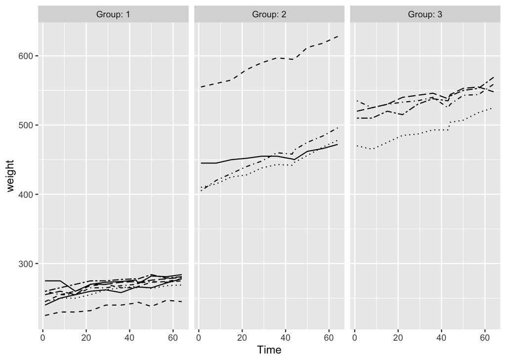

```r
#Access the packages
library(ggplot2)
library(tidyr)

# Draw the plot
ggplot(RATS_long, aes(x = Time, y = weight, linetype = ID)) +
  geom_line() +
  scale_linetype_manual(values = rep(1:10, times=4)) +
  facet_grid(. ~ Group, labeller = label_both) +
  theme(legend.position = "none")
```

We can see a huge difference between each group in term of weight from the beginning and this difference seems to stay over time so data points might be dependent to each other. The group 2 seems to have one rat’s weight very different than the others. Because of the massive difference let’s standardize the data so that the starting point does not influence the results and compare groups with standardized data.

**Analyze of standardized means of rat’s weight per group and per Time**

```r
# Standardise the variable weight
RATS2 <- RATS_long %>%
  group_by(Time) %>% # perform the next code lines per week
  mutate(stdweight = (weight - mean(weight)) / sd(weight)) %>% # add up the bprs result per week
  ungroup() # ungroup for the next use of this object.

# Glimpse the data
glimpse(RATS2)
```

```
## Rows: 176
## Columns: 6
## $ ID        <fct> 1, 2, 3, 4, 5, 6, 7, 8, 9, 10, 11, 12, 13, 14, 15, 16, 1, 2,…
## $ Group     <fct> 1, 1, 1, 1, 1, 1, 1, 1, 2, 2, 2, 2, 3, 3, 3, 3, 1, 1, 1, 1, …
## $ WD        <chr> "WD1", "WD1", "WD1", "WD1", "WD1", "WD1", "WD1", "WD1", "WD1…
## $ weight    <int> 240, 225, 245, 260, 255, 260, 275, 245, 410, 405, 445, 555, …
## $ Time      <int> 1, 1, 1, 1, 1, 1, 1, 1, 1, 1, 1, 1, 1, 1, 1, 1, 15, 15, 15, …
## $ stdweight <dbl> -1.0011429, -1.1203857, -0.9613953, -0.8421525, -0.8819001, …
```

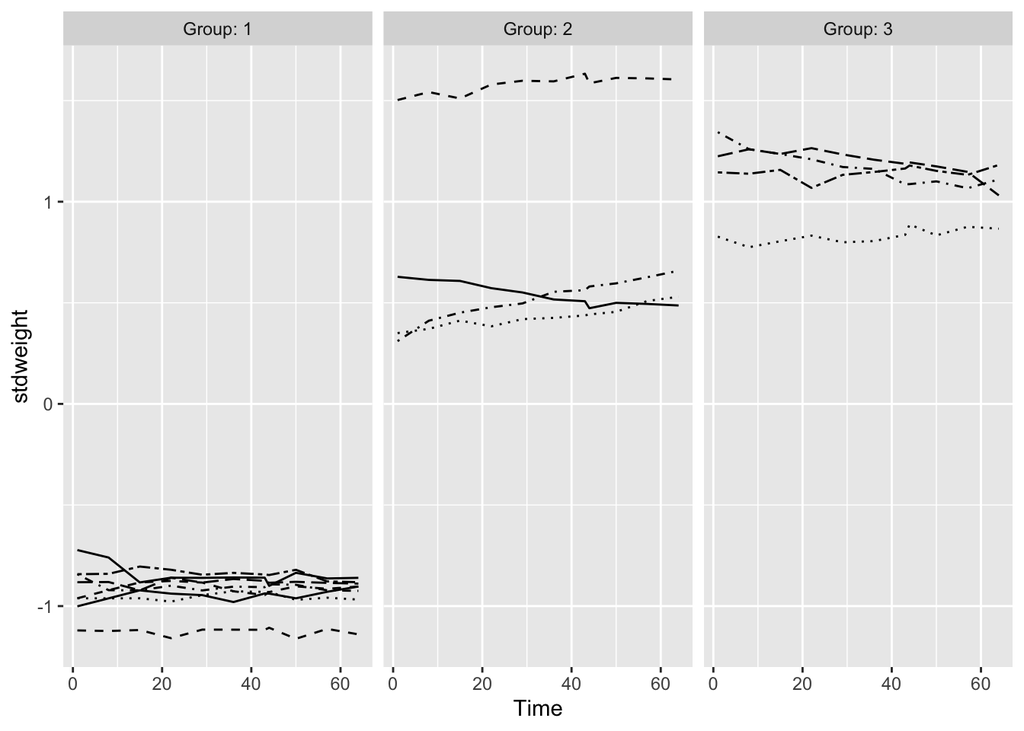

```r
# Draw the plot
ggplot(RATS2, aes(x = Time, y = stdweight, linetype = ID)) +
  geom_line() +
  scale_linetype_manual(values = rep(1:10, times=4)) +
  facet_grid(. ~ Group, labeller = label_both) +
  theme(legend.position = "none")
```

**Analyze of mean and standard deviation of the rats weights per group and per Time.**

```r
# Summary data with mean and standard error of weight
RATS3 <- RATS_long %>%
  group_by(Group, Time) %>%
  summarise(mean = mean(weight),
            sd = sd(weight),
            n = n()) %>%
  mutate(se = sd / sqrt(n)) %>%
  ungroup()
# Glimpse the data
glimpse(RATS3)
```

```
## Rows: 33
## Columns: 6
## $ Group <fct> 1, 1, 1, 1, 1, 1, 1, 1, 1, 1, 1, 2, 2, 2, 2, 2, 2, 2, 2, 2, 2, 2…
## $ Time  <int> 1, 8, 15, 22, 29, 36, 43, 44, 50, 57, 64, 1, 8, 15, 22, 29, 36, …
## $ mean  <dbl> 250.625, 255.000, 254.375, 261.875, 264.625, 265.000, 267.375, 2…
## $ sd    <dbl> 15.22158, 13.09307, 11.47591, 13.60081, 11.05748, 11.78377, 10.9…
## $ n     <int> 8, 8, 8, 8, 8, 8, 8, 8, 8, 8, 8, 4, 4, 4, 4, 4, 4, 4, 4, 4, 4, 4…
## $ se    <dbl> 5.381640, 4.629100, 4.057346, 4.808614, 3.909409, 4.166190, 3.87…
```

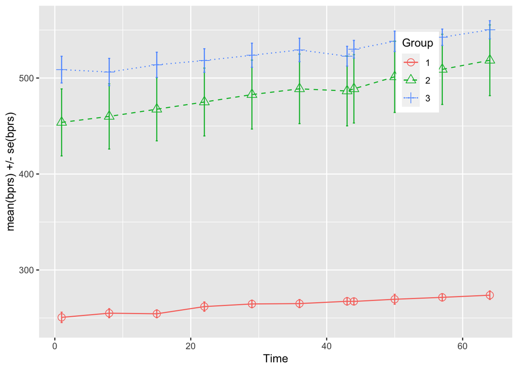

```r
# Plot the mean per group of rats
ggplot(RATS3, aes(x = Time, y = mean, linetype = Group, shape = Group, color = Group)) +
  geom_line() +
  scale_linetype_manual(values = c(1,2,3)) + # set the 3 different lines for the 3 groups
  geom_point(size=3) +
  scale_shape_manual(values = c(1,2,3)) + # set the 3 different point shapes for the 3 groups
  geom_errorbar(aes(ymin=mean-se, ymax=mean+se, linetype="1"), width=0.3) +
  theme(legend.position = c(0.8,0.8)) +
  scale_y_continuous(name = "mean(bprs) +/- se(bprs)")
```

This plot shos well the difference of weight per group but also withing group. It also shows well that the evolution over time depends on the starting point weight of a rat.

**Analyze of weights mean and standard deviation per group**

```r
# Create a summary data by group and ID with mean as the summary variable (ignoring baseline Time 0)
RATS4 <- RATS_long %>%
  filter(Time > 1) %>% # post first day.
  group_by(Group, ID) %>%
  summarise( mean=mean(weight) ) %>%
  ungroup()
# Glimpse the data
glimpse(RATS4)
```

```
## Rows: 16
## Columns: 3
## $ Group <fct> 1, 1, 1, 1, 1, 1, 1, 1, 2, 2, 2, 2, 3, 3, 3, 3
## $ ID    <fct> 1, 2, 3, 4, 5, 6, 7, 8, 9, 10, 11, 12, 13, 14, 15, 16
## $ mean  <dbl> 263.2, 238.9, 261.7, 267.2, 270.9, 276.2, 274.6, 267.5, 443.9, 4…
```

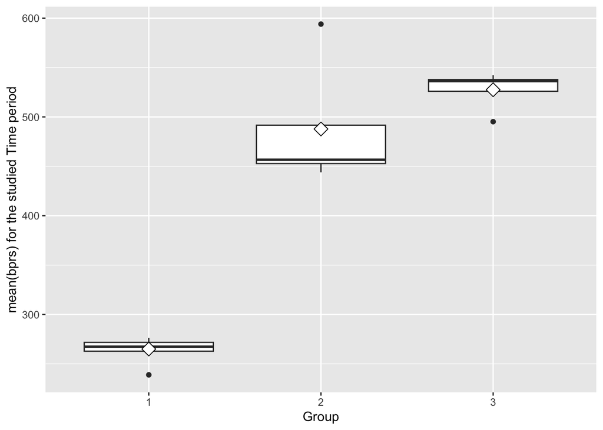

```r
# Draw a boxplot of the mean weight vs group
ggplot(RATS4, aes(x = Group, y = mean)) +
  geom_boxplot() +
  stat_summary(fun = "mean", geom = "point", shape=23, size=4, fill = "white") +
  scale_y_continuous(name = "mean(bprs) for the studied Time period")
```

**Analyze of weights mean and standard deviation per group- Removing the outliers**

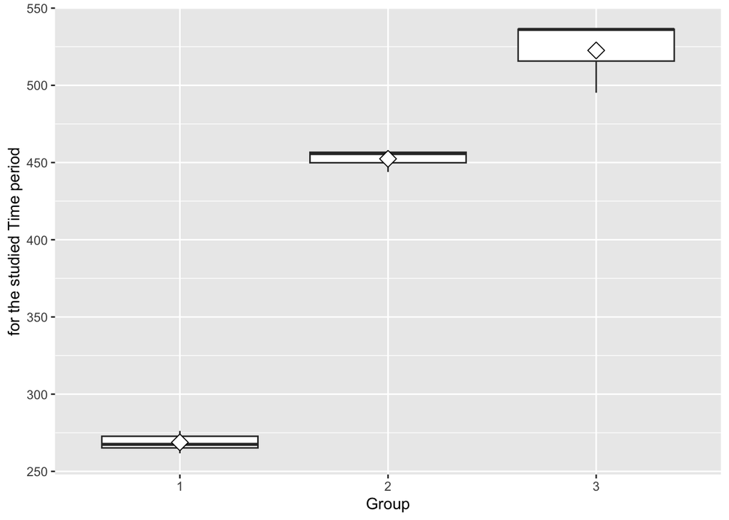

```r
# Create a new data by filtering the outliers and adjust the ggplot code the draw the plot again with the new data
RATS4_2 <- RATS4 %>%
  filter(mean > 240) %>%
  filter(mean < 540)

ggplot(RATS4_2, aes(x = Group, y = mean)) +
  geom_boxplot() +
  stat_summary(fun = "mean", geom = "point", shape=23, size=4, fill = "white") +
  scale_y_continuous(name = "for the studied Time period")
```

After outliers removal, the plot exhibits a more normally distributed pattern, making it easier to visualize trends and patterns in the data.

**Let’s create a linear model**

```r
# Save the Time 0 weigh of rats as an object to use it in the model
RATS4_3 <- RATS4 %>%
  mutate(baseline = RATS$WD1)

# Fit the linear model with the mean as the response (variables to influence weight are the baseline: situation in WD1 and the Group)
# We don't consider the rats individuality but more the group differences that impact the results but also their weight at the beginning of the study
fit_RATS <- lm(mean ~ baseline + Group, data = RATS4_3)

# summary of the model
summary(fit_RATS)
```

```
##
## Call:
## lm(formula = mean ~ baseline + Group, data = RATS4_3)
##
## Residuals:
##     Min      1Q  Median      3Q     Max
## -23.905  -4.194   2.190   7.577  14.800
##
## Coefficients:
##             Estimate Std. Error t value Pr(>|t|)
## (Intercept) 33.16375   21.87657   1.516   0.1554
## baseline     0.92513    0.08572  10.793 1.56e-07 ***
## Group2      34.85753   18.82308   1.852   0.0888 .
## Group3      23.67526   23.25324   1.018   0.3287
## ---
## Signif. codes:  0 '***' 0.001 '**' 0.01 '*' 0.05 '.' 0.1 ' ' 1
##
## Residual standard error: 11.68 on 12 degrees of freedom
## Multiple R-squared:  0.9936, Adjusted R-squared:  0.992
## F-statistic: 622.1 on 3 and 12 DF,  p-value: 1.989e-13
```

```r
anova(fit_RATS)
```

```
## Analysis of Variance Table
##
## Response: mean
##           Df Sum Sq Mean Sq   F value   Pr(>F)
## baseline   1 253625  253625 1859.8201 1.57e-14 ***
## Group      2    879     439    3.2219  0.07586 .
## Residuals 12   1636     136
## ---
## Signif. codes:  0 '***' 0.001 '**' 0.01 '*' 0.05 '.' 0.1 ' ' 1
```

```r
AIC(fit_RATS) # 129
```

```
## [1] 129.4492
```

```r
BIC(fit_RATS) # 133
```

```
## [1] 133.3121
```

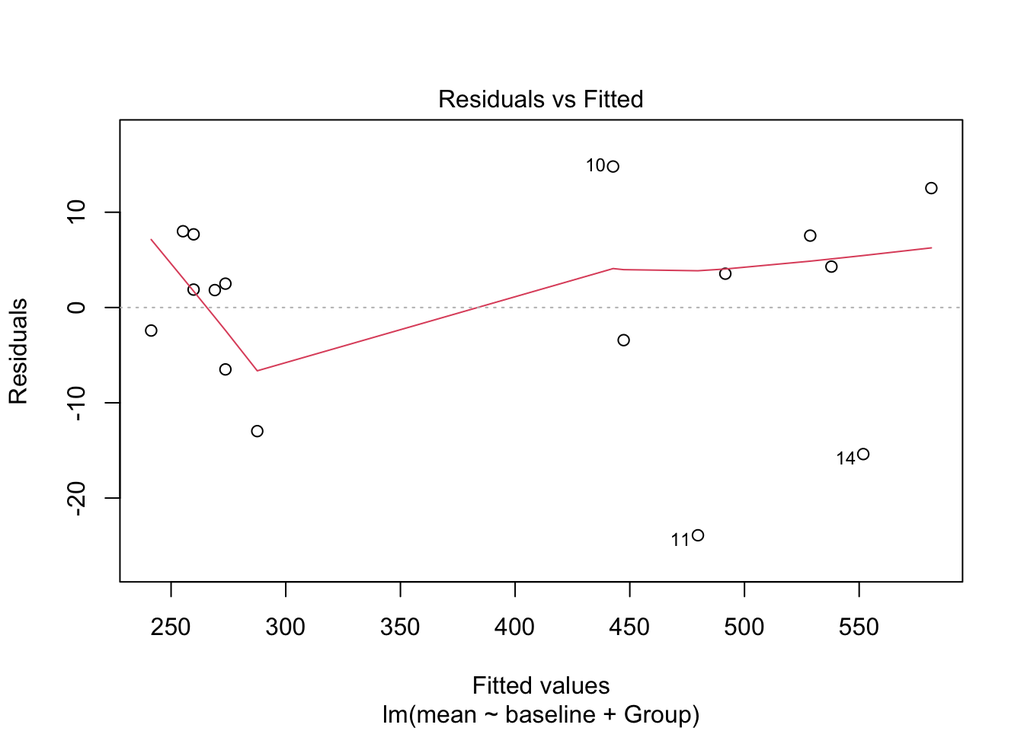

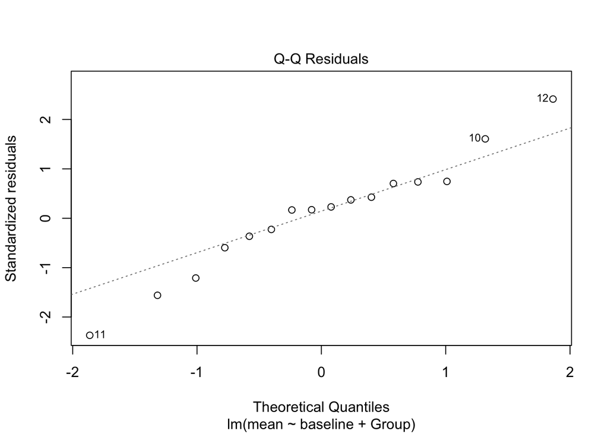

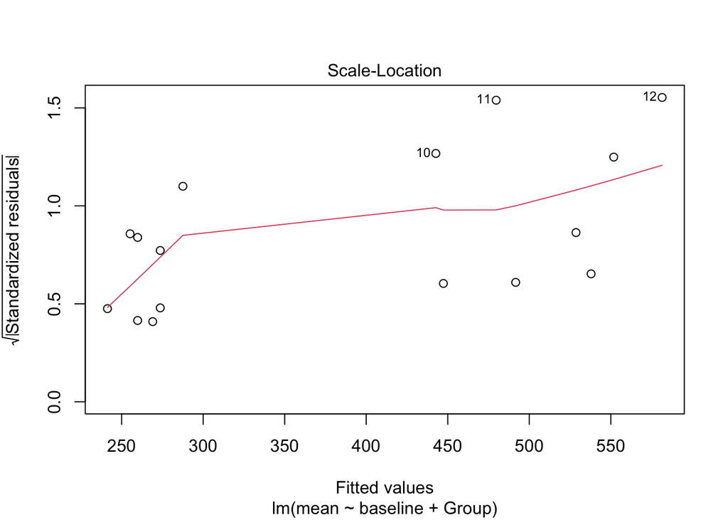

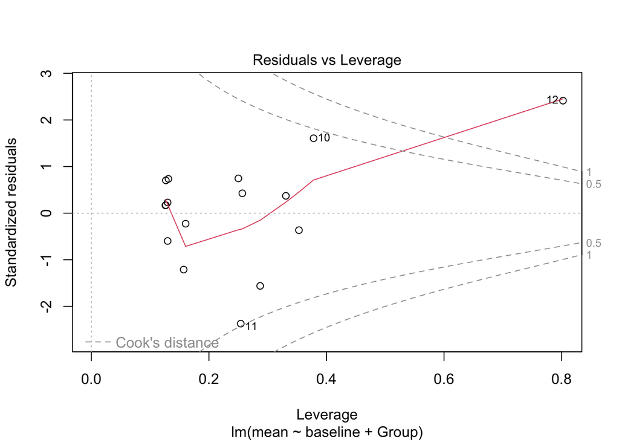

```r
plot(fit_RATS)
```

```r
# just for the try, let's remove baseline and see what is happening
# this model explain 92% but it is because there is a strong dependence between the data from one group and from each rat. Therefore there is a correlation that is not justified. This correlation might indicate interdependence that are not justified.
fit_RATS2 <- lm(mean ~ Group, data = RATS4_3)
summary(fit_RATS2)
```

```
##
## Call:
## lm(formula = mean ~ Group, data = RATS4_3)
##
## Residuals:
##     Min      1Q  Median      3Q     Max
## -43.900 -27.169   2.325   9.069 106.200
##
## Coefficients:
##             Estimate Std. Error t value Pr(>|t|)
## (Intercept)   265.02      12.98  20.419 2.92e-11 ***
## Group2        222.78      22.48   9.909 2.00e-07 ***
## Group3        262.48      22.48  11.675 2.90e-08 ***
## ---
## Signif. codes:  0 '***' 0.001 '**' 0.01 '*' 0.05 '.' 0.1 ' ' 1
##
## Residual standard error: 36.71 on 13 degrees of freedom
## Multiple R-squared:  0.9316, Adjusted R-squared:  0.9211
## F-statistic: 88.52 on 2 and 13 DF,  p-value: 2.679e-08
```

```r
anova(fit_RATS2)
```

```
## Analysis of Variance Table
##
## Response: mean
##           Df Sum Sq Mean Sq F value    Pr(>F)
## Group      2 238620  119310  88.525 2.679e-08 ***
## Residuals 13  17521    1348
## ---
## Signif. codes:  0 '***' 0.001 '**' 0.01 '*' 0.05 '.' 0.1 ' ' 1
```

```r
AIC(fit_RATS2) # 165
```

```
## [1] 165.383
```

```r
BIC(fit_RATS2) # 168
```

```
## [1] 168.4733
```

FIRST MODEL WITH BASELINE

- The T value of the baseline is 10.8, it is very high so it means this baseline impacts the studies weight (p is very small so it is significant). The estimate for the baseline variable remains significantly different from zero, even when considering its standard error, reinforcing its importance in explaining weight changes.

- Group Impact: Group 1 serves as reference. The coefficients for Group2 and Group3 which represent the differences between those groups and the baseline, aren’t as substantial, and their impact on weight might not be statistically significant based on the p-values.

- The spread of residuals looks decent, with the majority being relatively close to zero. However, there are a few larger residuals (especially the maximum value - the median is 2.19, and the values between the 1Q and 3Q range from -4.194 to 7.577), indicating potential areas where the model might not fit perfectly and where the fitted values are largely underestimated (but also overestimated). This is also very visible when analyzing the residuals plot.

- Similarly, the anova results suggests that the baseline has a strong and significant effect on the mean. Group might have some influence and shows a p-value of 0.076, indicating a relatively high significance threshold.

## Random Effects in Longitudinal Analysis - BPRS dataset

Implement the analyses of Chapter 9 of MABS, using the R codes of Exercise Set 6: Meet and Repeat: PART II, but using the BPRS data (from Chapter 8 and Meet and Repeat: PART I). (0-8 points: 0-4 points for graphs or analysis results + 0-4 points for their interpretations)

**Plot the data**

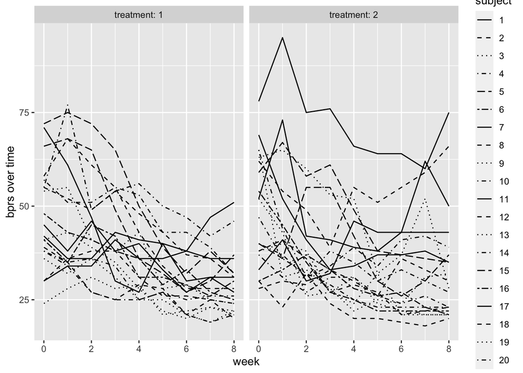

```r
# Draw a plot for each subject and its bprs per week
ggplot(BPRS_long, aes(x = week, y = bprs, linetype = subject)) +
  geom_line() +
  scale_linetype_manual(values = rep(1:10, times=4)) +
  facet_grid(. ~ treatment, labeller = label_both) +
  scale_y_continuous(name = "bprs over time")
```

**Creation of a linear model**

```r
# create a simple regression model
BPRS_model1 <- lm(bprs ~ week + treatment, data = BPRS_long)

# print out a summary of the model
summary(BPRS_model1)
```

```
##
## Call:
## lm(formula = bprs ~ week + treatment, data = BPRS_long)
##
## Residuals:
##     Min      1Q  Median      3Q     Max
## -22.454  -8.965  -3.196   7.002  50.244
##
## Coefficients:
##             Estimate Std. Error t value Pr(>|t|)
## (Intercept)  46.4539     1.3670  33.982   <2e-16 ***
## week         -2.2704     0.2524  -8.995   <2e-16 ***
## treatment2    0.5722     1.3034   0.439    0.661
## ---
## Signif. codes:  0 '***' 0.001 '**' 0.01 '*' 0.05 '.' 0.1 ' ' 1
##
## Residual standard error: 12.37 on 357 degrees of freedom
## Multiple R-squared:  0.1851, Adjusted R-squared:  0.1806
## F-statistic: 40.55 on 2 and 357 DF,  p-value: < 2.2e-16
```

```r
anova(BPRS_model1)
```

```
## Analysis of Variance Table
##
## Response: bprs
##            Df Sum Sq Mean Sq F value Pr(>F)
## week        1  12372 12371.5 80.9143 <2e-16 ***
## treatment   1     29    29.5  0.1927 0.6609
## Residuals 357  54584   152.9
## ---
## Signif. codes:  0 '***' 0.001 '**' 0.01 '*' 0.05 '.' 0.1 ' ' 1
```

```r
BIC(BPRS_model1) # 2852
```

```
## [1] 2852.881
```

```r
AIC(BPRS_model1) # 2837
```

```
## [1] 2837.337
```

Insights: the model explains only 18% of the variance which is very small. It suggests that a significant portion of the variability in the ‘bprs’ remains unexplained by the predictors in the model. Week has a big effect on the BPRS and It is significant. The high residual variability indicates the model is not effective to explain the ‘bprs’. It may be worth exploring other factors that could better explain the variability in ‘bprs’.

**Adding random effects to the model:**

Notes:

- Fixed Effects: Variables we are interested in and we want to estimate the effects or coefficients directly. They have a systematic impact on the response variable. Fixed effects are often the primary focus of analysis, while random effects account for additional variability that isn’t explicitly modeled as a primary predictor but impacts the variance.

- Random Effects: Variables we think impact the variability but not in a systemic manner.

For example, in a study analyzing subject’s ‘bprs’ based on different treatment, the subjects themselves might be included as a random effect because we’re not directly interested in the effect of the subjects, but we acknowledge that they may introduce variability in their ‘bprs’ that is not systematically related to other predictors.

```r
library(lme4) # to add random effects
library(lmerTest) # to get p value with random effects
# Create a random intercept model with subject only. The week does not effect on the subject.
BPRS_model2 <- lmer(bprs ~ week + treatment + (1 | subject), data = BPRS_long, REML = FALSE)

# Summary of the model
summary(BPRS_model2)
```

```
## Linear mixed model fit by maximum likelihood . t-tests use Satterthwaite's
##   method [lmerModLmerTest]
## Formula: bprs ~ week + treatment + (1 | subject)
##    Data: BPRS_long
##
##      AIC      BIC   logLik deviance df.resid
##   2748.7   2768.1  -1369.4   2738.7      355
##
## Scaled residuals:
##     Min      1Q  Median      3Q     Max
## -3.0481 -0.6749 -0.1361  0.4813  3.4855
##
## Random effects:
##  Groups   Name        Variance Std.Dev.
##  subject  (Intercept)  47.41    6.885
##  Residual             104.21   10.208
## Number of obs: 360, groups:  subject, 20
##
## Fixed effects:
##             Estimate Std. Error       df t value Pr(>|t|)
## (Intercept)  46.4539     1.9090  37.2392  24.334   <2e-16 ***
## week         -2.2704     0.2084 340.0000 -10.896   <2e-16 ***
## treatment2    0.5722     1.0761 340.0000   0.532    0.595
## ---
## Signif. codes:  0 '***' 0.001 '**' 0.01 '*' 0.05 '.' 0.1 ' ' 1
##
## Correlation of Fixed Effects:
##            (Intr) week
## week       -0.437
## treatment2 -0.282  0.000
```

```r
anova(BPRS_model2)
```

```
## Type III Analysis of Variance Table with Satterthwaite's method
##            Sum Sq Mean Sq NumDF DenDF  F value Pr(>F)
## week      12371.5 12371.5     1   340 118.7136 <2e-16 ***
## treatment    29.5    29.5     1   340   0.2828 0.5952
## ---
## Signif. codes:  0 '***' 0.001 '**' 0.01 '*' 0.05 '.' 0.1 ' ' 1
```

```r
BIC(BPRS_model2) # 2768
```

```
## [1] 2768.143
```

```r
AIC(BPRS_model2) # 2748
```

```
## [1] 2748.712
```

From the F values, it seems that the “week” factor has a much higher F value compared to the “treatment” factor, suggesting once again that the “week” factor explains more variability in the data compared to the “treatment” factor.

This model is bit better than the previous one when considering the BIC and AIC. This model does not take into consideration the fact that each subject may have different evolution of ‘bprs’ over time, therefore let’s try a new model that would take into consideration this random effect.

**Mixed model with random effects - week and subject**

- Individual Variability: If each subject indeed has different baseline levels (‘bprs’ at the start), a random intercept for ‘subject’ ((1 | subject)) might be appropriate.
- Varying Response to Time: If time affects individuals differently, incorporating random slopes for ‘week’ within ‘subject’ ((week | subject)) might be beneficial.

```r
# create a random intercept and random slope model
library(lme4)
BPRS_model3 <- lmer(bprs ~ week + treatment + (week | subject), data = BPRS_long, REML = FALSE)

# summary of the model
summary(BPRS_model3)
```

```
## Linear mixed model fit by maximum likelihood . t-tests use Satterthwaite's
##   method [lmerModLmerTest]
## Formula: bprs ~ week + treatment + (week | subject)
##    Data: BPRS_long
##
##      AIC      BIC   logLik deviance df.resid
##   2745.4   2772.6  -1365.7   2731.4      353
##
## Scaled residuals:
##     Min      1Q  Median      3Q     Max
## -2.8919 -0.6194 -0.0691  0.5531  3.7976
##
## Random effects:
##  Groups   Name        Variance Std.Dev. Corr
##  subject  (Intercept) 64.8222  8.0512
##           week         0.9609  0.9802   -0.51
##  Residual             97.4305  9.8707
## Number of obs: 360, groups:  subject, 20
##
## Fixed effects:
##             Estimate Std. Error       df t value Pr(>|t|)
## (Intercept)  46.4539     2.1052  22.6795  22.066  < 2e-16 ***
## week         -2.2704     0.2977  19.9991  -7.626 2.42e-07 ***
## treatment2    0.5722     1.0405 320.0005   0.550    0.583
## ---
## Signif. codes:  0 '***' 0.001 '**' 0.01 '*' 0.05 '.' 0.1 ' ' 1
##
## Correlation of Fixed Effects:
##            (Intr) week
## week       -0.582
## treatment2 -0.247  0.000
```

```r
# ANOVA test on the two models.
anova(BPRS_model2, BPRS_model3)
```

```
## Data: BPRS_long
## Models:
## BPRS_model2: bprs ~ week + treatment + (1 | subject)
## BPRS_model3: bprs ~ week + treatment + (week | subject)
##             npar    AIC    BIC  logLik deviance  Chisq Df Pr(>Chisq)
## BPRS_model2    5 2748.7 2768.1 -1369.4   2738.7
## BPRS_model3    7 2745.4 2772.6 -1365.7   2731.4 7.2721  2    0.02636 *
## ---
## Signif. codes:  0 '***' 0.001 '**' 0.01 '*' 0.05 '.' 0.1 ' ' 1
```

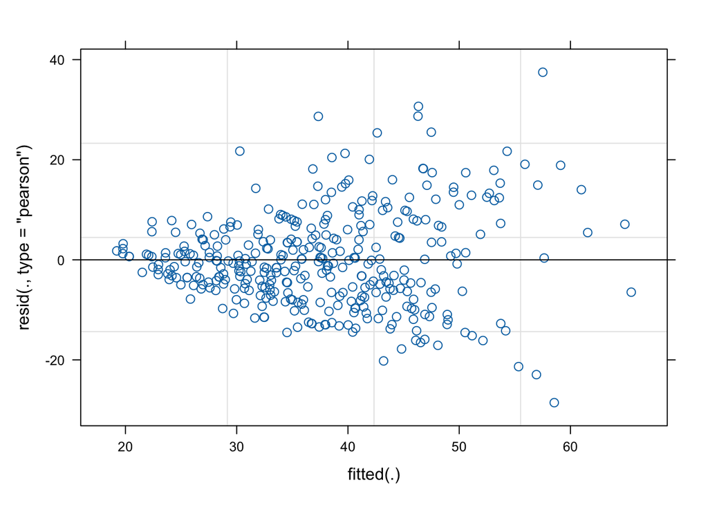

```r
# plot the residuals
plot(BPRS_model3)
```

In BPRS_model2: (1 | subject) represents a random intercept for each ‘subject’. The variance associated with this random intercept (subject-specific variability that is not explained by fixed effects) is estimated in this model.

In BPRS_model3: (week | subject) represents both random intercepts and random slopes for ‘week’ within each ‘subject’. This allows the ‘week’ effect to vary for each ‘subject’. This models seems to be better since we can see on the first plot that each individual has a very different ‘bprs’ slope per subject and this difference per subject exist over time.

Comparison between the 2 models:

- BPRS_model2 has 5 estimated parameters and a higher AIC (2748.7) and a lower BIC (2768.1).The BIC is lower because the BIC penalizes the more complex models (favorizing the model with 5 vs 7 parameters)

- BPRS_model3 has 7 estimated parameters and slightly lower AIC (2745.4) and a higher BIC (2772.6) compared to BPRS_model2.

- The chi-square test for model comparison results in a p-value of 0.02636 for the model3, indicating that BPRS_model3 significantly improves the model fit compared to BPRS_model2.

- BPRS_model3 has a higher log-likelihood (-1365.7) compared to BPRS_model2 (-1369.4). Therefore, based solely on the logLik values, BPRS_model3 appears to provide a better fit to the data than BPRS_model2.

- The lower deviance values of the BPRS_model3 implies that the model explains a larger proportion of the total variance in the data vs the other model.

To conclude, the BPRS_model3 seems to provide a better fit for the data compared to BPRS_model2 due to its lower AIC, deviance, higher logLik, and its significant improvement in model fit indicated by the chi-square test.

**Model3 analyzes:**

The model captures a significant effect of ‘week’ on ‘bprs’ scores, indicating a decrease in ‘bprs’ over time.

- The scaled residuals range from -2.8919 to 3.7976, indicating a relatively wide spread of values = heteroscedasticity in the residuals which we can also observe in the residuals plot. The scaled residuals are close to zero (around -0.0691) implies that a substantial portion of the observations have residuals near the mean. The negative scaled residuals (-2.8919) are less extreme compared to the positive scaled residuals (3.7976). It suggests that the model more often underestimates the ‘bprs’ (a positive residual (observed - predicted > 0) indicates an underestimation by the model.)

- The estimated variance of the effect of ‘week’ among subjects is 0.9609, with a standard deviation of 0.9802. The deviation suggests that for certain subjects, time does not significantly affect their ‘bprs’ scores but for others it does.

**Mixed model with random effects - week and subject + consider bprs change over time, based on treatment**

Note: week and treatment both influences each other. We use the ‘*’ if there’s reason to believe that the effect of week on bprs differs if treatment is taken or not. If there’s no reason to believe that the relationship between week and bprs changes based on treatment, using the model week + treatment is sufficient.

```r
# create a random intercept and random slope model with the interaction
BPRS_model4 <- lmer(bprs ~ week * treatment + (week | subject), data = BPRS_long, REML = FALSE)

# print a summary of the model
summary(BPRS_model4)
```

```
## Linear mixed model fit by maximum likelihood . t-tests use Satterthwaite's
##   method [lmerModLmerTest]
## Formula: bprs ~ week * treatment + (week | subject)
##    Data: BPRS_long
##
##      AIC      BIC   logLik deviance df.resid
##   2744.3   2775.4  -1364.1   2728.3      352
##
## Scaled residuals:
##     Min      1Q  Median      3Q     Max
## -3.0512 -0.6271 -0.0768  0.5288  3.9260
##
## Random effects:
##  Groups   Name        Variance Std.Dev. Corr
##  subject  (Intercept) 64.9964  8.0620
##           week         0.9687  0.9842   -0.51
##  Residual             96.4707  9.8220
## Number of obs: 360, groups:  subject, 20
##
## Fixed effects:
##                 Estimate Std. Error       df t value Pr(>|t|)
## (Intercept)      47.8856     2.2521  29.6312  21.262  < 2e-16 ***
## week             -2.6283     0.3589  41.7201  -7.323 5.24e-09 ***
## treatment2       -2.2911     1.9090 319.9977  -1.200   0.2310
## week:treatment2   0.7158     0.4010 319.9977   1.785   0.0752 .
## ---
## Signif. codes:  0 '***' 0.001 '**' 0.01 '*' 0.05 '.' 0.1 ' ' 1
##
## Correlation of Fixed Effects:
##             (Intr) week   trtmn2
## week        -0.650
## treatment2  -0.424  0.469
## wek:trtmnt2  0.356 -0.559 -0.840
```

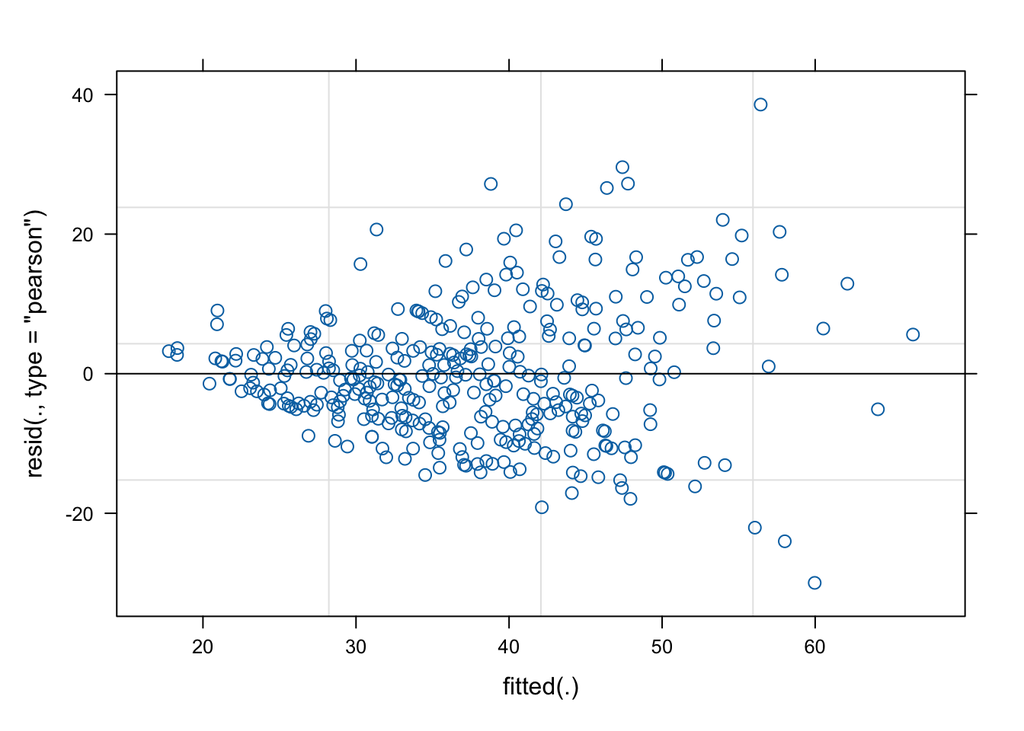

```r
plot(BPRS_model4)
```

```r
# perform an ANOVA test on the 3 models
anova(BPRS_model2,BPRS_model3,BPRS_model4)
```

```
## Data: BPRS_long
## Models:
## BPRS_model2: bprs ~ week + treatment + (1 | subject)
## BPRS_model3: bprs ~ week + treatment + (week | subject)
## BPRS_model4: bprs ~ week * treatment + (week | subject)
##             npar    AIC    BIC  logLik deviance  Chisq Df Pr(>Chisq)
## BPRS_model2    5 2748.7 2768.1 -1369.4   2738.7
## BPRS_model3    7 2745.4 2772.6 -1365.7   2731.4 7.2721  2    0.02636 *
## BPRS_model4    8 2744.3 2775.4 -1364.1   2728.3 3.1712  1    0.07495 .
## ---
## Signif. codes:  0 '***' 0.001 '**' 0.01 '*' 0.05 '.' 0.1 ' ' 1
```

**Analyze the fitted vs observed values with the model 3**

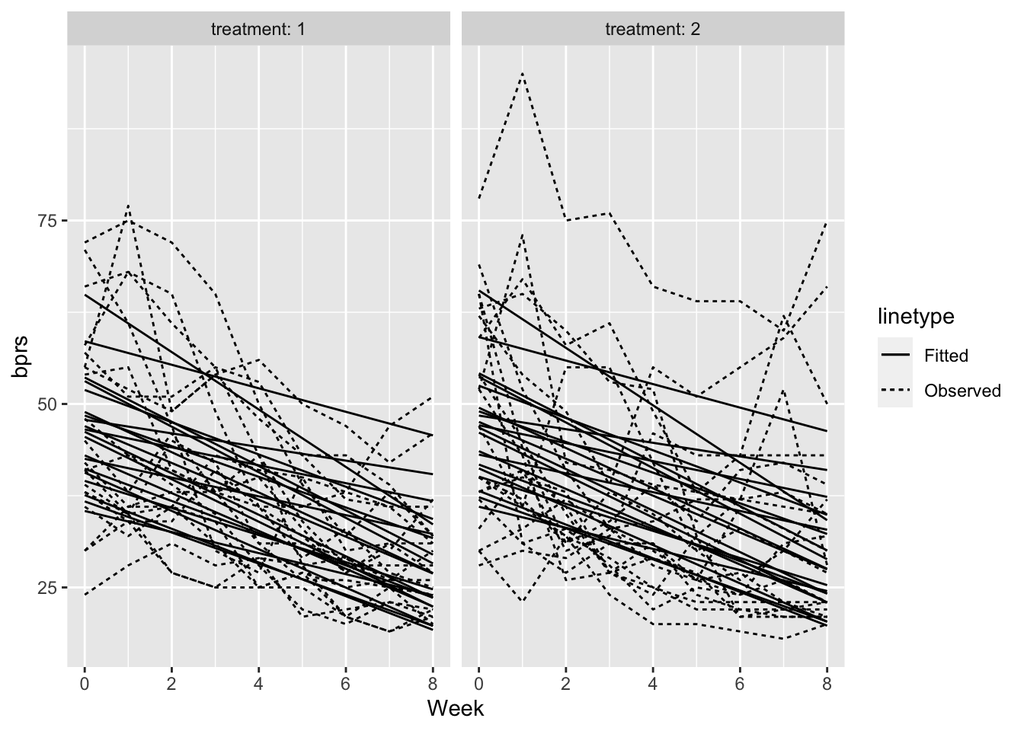

```r
# Create a vector of the fitted values of model 3 - our best model
Fitted_bprs <- fitted(BPRS_model3)

# Create a new column fitted to our BPRS_long dataset
BPRS_new <- BPRS_long %>%
  mutate(Fitted_bprs = Fitted_bprs)

# draw the plot for the subjects, observed vs fitted values:
ggplot(BPRS_long, aes(x = week)) +
  geom_line(aes(y = bprs, group = subject, linetype = "Observed")) +
  geom_line(aes(y = Fitted_bprs, group = subject, linetype = "Fitted")) +
  facet_grid(. ~ treatment, labeller = label_both) +
  labs(x = "Week", y = "bprs")
```

Note: It does not seem to be such a good model to predict the BPRS of subject in each treatment group. The example we saw in the book with the RATS dataset was better.